# GroupTrack — Quick Start

Rel 2.7b · install and set up, practise on the two maps — and add a radio to experience full group awareness while riding: no new software, nothing to learn. Every section points you to the User Manual for the detail.

**GroupTrack is complete as installed** — trails and maps that work with no signal, a planner that builds routes for you, and your own track recordings.

**New: ★ Create a Ride.** One ride holds the route, the trailhead, the date and time, the maps to download and the mesh radio configuration. **Send it in one click; your friends open it in one click** — and ride anywhere off grid in total confidence.

**Add a radio to experience full group awareness while riding** — no new software, nothing to learn: everyone on the map, with no cell service. GroupTrack is two products in one: a complete personal navigation product that lets you share rides and maps with other GroupTrack users, and a true situational awareness product for your group on the trail. (About GroupTrack)

**Coming in 2.7c: One Map.** The ride map and the planning map become one map, with every tool reached from the buttons around its edge. While it is being finished you can try it in **Settings › Layout › One Map**; these exercises still describe the two maps until 2.7c is released. (What is in 2.7c so far)

**★ Before every ride: send the ride invite to every rider.** **Everyone on the ride needs the same ride.** Send the ride invite to **every GroupTrack rider** joining you — and make sure each one **opens it and imports it before the ride**. The ride brings the **route**, the **trailhead** and the **maps**. Without it, a rider sees carts as dots on an empty map and has nothing to follow. **It matters even with no radio:** a rider who has imported the ride can follow the route on their own tablet, and stays on course far more easily. (Sending a ride)

**How to use this.** Each section says in a paragraph what something is, with a link to its chapter in the **User Manual**. The exercises under it are short practice tasks — each links to the manual section that explains it in full. Open the manual any time from **Help**.

## 1 · Install, and first start

GroupTrack keeps your trails, tracks, routes and downloaded maps in its own storage on the device. Nothing you do here puts files anywhere else, and you are not asked for access to your phone's folders.

If you are updating from an older version, the first launch moves your existing data across for you — follow the prompt and leave the screen open while it works.

**Grant the app the authorities it needs** — location, all the time. Follow the prompts.  
**Fill in your rider profile** — your callsign and email. GroupTrack asks once, before the map opens.  
**Answer the radio question** — *Do you have a mesh radio to use with GroupTrack?* **YES**: switch the radio on; GRP Awareness opens — connect it, then **Select a ride and apply settings to the radio → GroupTrack default**. Pairing code 123456 unless your radio shows another. **NO**: do it later in GRP Awareness, before your first ride. **New in 2.7b:** the question becomes *Will you use a Meshtastic radio to see your group on the map?* — **YES, I HAVE A RADIO** / **NO, THIS TABLET ONLY** (group awareness off; switch it on any time in Settings → Group awareness).  
**Choose your home state** and let it download the trails, so they work with no signal.  
**When the app loads your location, you are ready to play.**

That is the whole of it. The detail below is worth reading when you have a moment — none of it is needed to get going.

**Loading the trails for your home state**

On first launch GroupTrack asks for location, then asks which state you ride in and offers the one it thinks you are in.

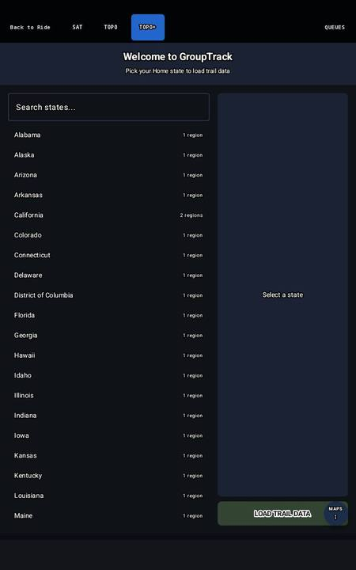

Pick your home state and load the trail data.

**Pick your state and let it run.** It takes about twenty minutes and pulls a lot of data, so do it on wifi. It is not something to start at the trailhead.

- **Utah Trails and Pathways** — the state's own trail record
- **US Forest Service**, **Bureau of Land Management**, **National Park Service**, **USGS National Trails** — the federal agencies that manage the ground
- **Arizona State Parks** — border coverage
- **OpenStreetMap** — the largest single source, and the one that carries tracks and unclassified roads the agencies do not list

Another state draws on a different set. The app picks the sources that cover the area you asked for.

It also downloads the **land ownership record** for your state, which is what lets it tell public ground from private.

**When it finishes you get a summary** listing every source and what came in. It waits for you — if you put the tablet down and come back later, it is still there. ⚠ If a line says a source failed, the rest still loaded; you can reload the state later from the same place.

**Choosing what appears on the map**

GroupTrack holds around 146,000 trails for Utah. Most of what is in that number is ground you will never ride — footpaths, residential streets, cycle paths through town. Choosing what appears is how the map becomes readable.

[figure not shown]

Map Features › Trails › SELECT — choose which kinds of trail appear.

### What you get out of the box

GroupTrack starts by showing **motorized trails on public land only**. Hiking, biking and equestrian trails are hidden, and so is private ground.

⚠ **If a trail you know exists is not on the map, that is why** — not a fault. It is a deliberate choice for an off-road app, and it is the first thing worth knowing.

### Changing it

**Map Features › Trails › SELECT.** The same button you use to choose which tracks, waypoints or routes appear.

- **Include private land** — one tick. Near a town this is what removes the residential street grid, which is usually why a map is hard to read there.
- **The trail types**, in two columns: motorized and non-motorized. Tap a row to hide that type; tap a column heading for the whole group.

And **OFF** on the Trails row hides every trail in one tap, for when you want to see the ground.

### Not sure what a category is?

Press **CATEGORIES EXPLAINED** at the foot of the Map Keys panel. It says what each trail type actually means — which are posted for machines, which are open unless a sign says otherwise, and which came from your own rides.

### The colours are yours

Whatever you set is what the map draws, every time you open it. You do not need to visit the key panel again for your choices to take effect.

**Solid lines are motorized. Dotted lines are not.** That is the distinction worth learning, and it is one you can read in sunlight without picking colours apart.

Tap **Map Keys** to see what each line means, and **tap any name in that list** to change its colour, pattern or thickness. It shows the line as it is beside the line as it would be, so you can compare before committing. What you choose is saved.

### Your rider profile

Your profile — your callsign and your email — is who you are in GroupTrack. Your **callsign** is your name on every map and in every report your radio sends; your **email** is how rides reach you. It is private: it stays on your tablet, and goes only to the riders you ride with. GroupTrack asks for it the first time it opens; change it any time in **Settings → Your Profile**.

Manual: Your rider profile

### Opening your first ride

The first time you tap a ride someone sent you, Android asks which app should open it: choose **GroupTrack**, then **Always**. The route, trailhead and waypoints arrive, and the maps along the route start downloading. If ride files open somewhere else: Android **Settings → Apps → GroupTrack → Open by default → Clear defaults**, then tap the file again.

Manual: Sending a ride, and getting one

### Updating from 2.6?

Three one-time steps — your rider profile, updating your radio once, and opening ride files with GroupTrack — are in the release notes: Updating from 2.6.

## ★ Create your first ride — new in 2.7a

**Riding together starts with a ride.** GroupTrack's community begins with the **ride package** — a route, starting at its defined trailhead, on a set date and time, with the maps it needs and its radio configuration. Send it to friends and riders who want to ride with you.

**One click, and everyone has the same preparation:** the trailhead marked on their map, the route outlined to follow, the required maps downloaded along it. At the trailhead, **check-in applies the ride's radio configuration for them.** **The fastest way to create one is a map touch:** tap a route or a track on the Ride Planning Map, then **CREATE RIDE** — Manual: Map touches, the fastest way to Create a Ride.

**No more night before the ride** spent downloading an area and hoping the trail goes where you think it does. No one asks where to meet, and no one waits at the trailhead while someone else catches up. Everyone's time goes to riding.

**Create a ride and send it**

1. On the **Ride Planning Map**, tap a route. A route the planner built opens its description — tap **CREATE RIDE**; a route you drew opens its details — tap **ADD A RIDE**. (From a track you recorded: tap it, then **CREATE RIDE**.)
2. The ride form opens with the route, its trailhead and its picture. Set the date and time, fill in the rest, **SAVE RIDE**.
3. **Work with Rides → Rides**, tap your ride, **Share** — the invite goes to your riding partners.

Manual: ★ Create a Ride · Sending a ride, and getting one

## 2 · Exercises — the Ride Planning Map

### What a ride is

A ride is everything a group needs to ride together, in one package: the route and its trailhead, waypoints, the maps for riding off grid, and the radio settings for the ride's network. The organizer builds it on a route — or a track they rode — and sends it as a **Ride invite**. Each rider — any GroupTrack user — taps it: GroupTrack creates the route, its trailhead and the ride's description on the tablet, and imports the maps needed to ride it off grid. Then they ride; with a radio, riders also check in at the trailhead.

Manual: The Ride — what are its components, and what does it mean to me?

The map you use at home, online, before you go: find the ground, build a route or let the planner build one, mark waypoints, download the maps you will need, and create and send rides. Every control is lettered on the picture in its chapter.

Manual: The Ride Planning Map

Training exercises

**Find a place, and change the map underneath**

1. Tap **Search** and type a town or area, followed by its two-letter state.
2. Switch between **SAT**, **TOPO** and **TOPO+**.

Manual: Search · SAT, TOPO and TOPO+

**Show only what you need**

1. Open **Map Features**.
2. Turn a category of trails off, then back on.

Manual: Map Features · Controlling how map features are displayed

**Draw a route yourself**

1. Map Features → **Route+**, and choose to draw it yourself.
2. Drop pins along the way; the line snaps to the trails.
3. Save it — name its trailhead if asked.

Manual: Drawing a route yourself · Creating a route

**Let the planner build routes**

1. Route+ → let the planner build it.
2. Answer its questions: trailhead, distance and pace, places to pass through.
3. Compare the routes it returns; keep the ones you like.

Manual: Letting the planner build it

**Add a waypoint**

1. Long press on open map.
2. New Waypoint opens with **Trailhead** chosen; pick a type, name it, **Create**.
3. Tap the waypoint: its details open — try **CHANGE TYPE**.

Manual: Long press — add a waypoint · A waypoint

**Download the maps along a route**

1. Tap a route on the map, then **SAVE MAPS** (detail panel) — or **DOWNLOAD MAPS** on a planner route's description.
2. Watch the progress in **QUEUES**.

Manual: Along a route · QUEUES

**Create a ride from a route**

1. Tap a route on the map. A route the planner built opens its description — tap **CREATE RIDE**. A route you drew yourself opens the detail panel — tap **ADD A RIDE**.
2. Fill in the ride form, **SAVE RIDE**. The radio network is the **GroupTrack default** unless you choose your own or a private one.

Manual: Creating a ride from a route · The ride form

**Create a ride from a track you recorded**

1. Tap a track, then **CREATE RIDE**.
2. Name the trailhead if asked, name and describe the route; the ride form opens.

Manual: Creating a ride from a track

**Send a ride, and open one**

1. **Work with Rides → Rides**, tap your ride, **Share**.
2. On the receiving tablet: tap the **Ride invite** (the first time, choose **GroupTrack**, then **Always**). GroupTrack creates the route, its trailhead and the ride's description on the tablet, and imports the maps needed to ride it off grid.

Manual: Sending a ride, and getting one · Work with Rides

## 3 · Exercises — the Ride Map

The map you use in the field: simple and focused. Record your track, read the trail, find yourself and your group. Every control is lettered on the picture in its chapter.

Manual: The Ride Map

Practice exercises

**Record a track on your own**

1. **New in 2.7b:** a light above **REC** turns green — **GPS LOCK** — when the tablet has its position. The first time, give it about five minutes outside, then press REC.
2. With no radio connected, the button reads **⏺ REC** — tap it. There is no check-in when you ride solo.
3. Ride, or walk round the block.
4. Tap **END** and save the track.

Manual: CHK IN › REC · Checking in and recording your track

**Read the map**

1. Switch **SAT**, **TOPO**, **TOPO+**.
2. Open **Map Keys** to see what each line means.
3. A trail you expect is missing? **Settings → Check a trail**, then **SEND** to support.

Manual: SAT, TOPO and TOPO+ · Map Keys

**Find yourself, and the group**

1. Tap **MY CART**: the map centres on you and follows you.
2. Tap **GROUP**: the map fits everyone, and the readout shows the group.

Manual: MY CART · GROUP, and the readout

**Tap a waypoint**

1. Tap a waypoint on the map; its details open.
2. Change its type, or close the panel.

Manual: Tapping a feature on the map

**Unclutter the map**

1. Tap **HIDE**, then bring the controls back.

Manual: HIDE

**Ride your route the right way (2.7b)**

1. Open a ride's route on the Ride Map: arrows along it show the direction it was built to be ridden.
2. Turn the tablet's Wi-Fi off and open the Ride Map again: it opens on your cart, on your downloaded maps.

Manual: Map Features · The Ride Map

## 4 · Group awareness

**Add a radio to experience full group awareness while riding — no new software, nothing to learn.** Your community comes onto the trail with you. Group awareness is seeing your group on the map with no cell service — every cart where it is, with its callsign and role. It needs a **Meshtastic radio** for each rider; GroupTrack works with any Meshtastic radio and sets it up for you. Checking in to a ride puts your radio on the ride's network and announces your role — the check-in is part of group awareness: riding solo, you never see its screens. Riding alone? Skip this section.

Manual: Group Awareness

Practice exercises — with a radio

**Connect your radio**

1. Tap **GRP Awareness** on either map.
2. **PAIR** a new radio (or **CONNECT** one you have used); the label turns green.
3. **New in 2.7b:** tap **NODES** to see the radios heard, then **BACK TO MAP**.

Manual: GRP Awareness

**Give your radio the GroupTrack default**

1. Said YES at first start? This is already done. Otherwise: **GRP Awareness → Select a ride and apply settings to the radio → GroupTrack default → Apply** (or Work with Rides → Apply ride to radio / Nucleus).
2. Leave the screen open until every setting is ticked.

Manual: Setting up your radio

**Check in to a ride, and record**

1. Tap **✔ CHK IN › REC**, choose the ride and your role, **CHECK IN**.
2. If asked, let GroupTrack set your radio up for the ride (about a minute).
3. No ride today? Choose **No scheduled ride**: your radio goes back to the GroupTrack default — tick **Keep my radio as it is** to leave it.
4. Tap **⏺ REC** when the group rolls out; **END** at the finish.

Manual: Checking in and recording your track

**See the carts, and change your role**

1. Tap **VIEW CART ROLES**: the carts on your ride, Leader, Middle and Tail gunner first — green ✔ checked in, red ● not yet.
2. Try **REMOVE** and **ACTIVATE** on another cart.
3. Tap your own cart: **Change my role**.
4. **New in 2.7b:** roles show only while you are checked in, and the lead is whoever holds Leader. If two of you claim the same role, a flashing red **ROLE CONFLICT** sets you both back to Rider — agree, and one of you claims it again.

Manual: VIEW CART ROLES · Roles on the trail

**Set up a guest's radio**

1. **Work with Rides → Apply ride to radio / Nucleus** with their radio connected.
2. Choose the ride, type **their callsign**, Apply.

Manual: Apply ride to radio / Nucleus

**How often your location is sent**

1. Tap the **GPS** button on the Ride Map.
2. Read the channel colour; set a new interval (3–10 s) and **APPLY**.

Manual: GPS